# Sentiment Analysis

John Howard, Frankie Lara, Robert Surane, Chloe Liu

June 5, 2016

## **Introduction**

Sentiment analysis is a statistical method that examines text data (in this project, with R) for subjective information. This is applicable in the realm of reviews, news releases, and social media, such as Twitter. In general, the goal of sentiment analysis is to determine the attitude of a speaker or writer in regards to some topic, or simply the overall polarity (positive/negative) in a set of text data. For example, we can determine if people generally like or dislike a presidential candidate or are optimistic about a certain stock.

In this project, we will obtain sets of text data by downloading a large number of tweets (mostly subjective posts/statements of 140 characters or less) from Twitter. These lists of tweets will be cleaned to remove capitalization, punctuation, digits, links, whitespace, unicode characters, and emoticons. Following this, the lists will run through functions in R counting the total number of positive, negative, and emotionally related words used throughout the tweets. This count will be translated into a sentiment score that can be used to determine a person’s overall attitude. Sentiment analysis is useful in a vast array of topics; this project will focus on the 2016 Presidential Election and the LA Dodgers vs. the SF Giants.

## **Statistical Concepts**

For our datasets, our variables are the count of each type of different emotive word found per tweet: anger, anticipation, disgust, fear, joy, sadness, surprise, trust, negative, and positive.

Using Univariate One-Way ANOVA, we can analyze whether the average amount of a certain emotion per tweet differs across different populations of tweets. In this project, Univariate One-Way ANOVA can be used to determine if there is a significant difference in a certain attitude between presidential candidates’ tweets or tweets concerning MLB teams in rival cities.

We will also utilize Multivariate One-Way ANOVA to analyze whether the average amounts of the different emotions per tweet jointly differs across different populations. In this project, Multivariate One-Way ANOVA can be used to determine if there is a significant difference in overall attitude, or sentiment, between presidential candidates’ tweets or tweets concerning MLB teams in rival cities.

## **R Functions used**

- spread - makes large numbers smaller and small numbers larger to make words more visible
- clean.text - uses Regular Expressions to clean out tweets of punctuation, links, handles (@…).
- wordcloud - generates a word cloud, given two input files.
- get.tweets.user/get.tweets.search - downloads last n tweets from specified users or specified search
- score.sentiment - gets a score indicating whether the sentences are mostly positive, negative, or neutral.

## **Libraries Used**

- twitteR
- ROAuth
- tm
- ggplot2
- dplyr
- syuzhet
- tidyr
- stringr
- ggmap
- plyr
- wordcloud

## **Data Sets**

### Presidential Debate

To analyze the sentiment of the 2016 Presidential candidates, we set parameters to gather the 10,000 most recent tweets posted by tue Twitter account of each candidate, “BernieSanders”, “HillaryClinton”, and “RealDonaldTrump”. Overall, each candidate only tweeted around 3200 posts; however, we believe this is enough data to make a sufficient analysis.

### MLB Teams

**Below is a list of the data we gathered with their respective number of observations.**

#### Presidential Debate

Bernie Sanders- 3193 Observations Donald Trump- 3188 Observations Hillary Clinton- 3198 Observations

### Sentiment Polarity Scoring

We used the NRC Word-Emotion Association Lexicon which is a list of English words and their associations with eight basic emotions (anger, fear, anticipation, trust, surprise, sadness, joy, and disgust) and two sentiments (negative and positive). These were used to categorize the emotions of tweets for each of the above data sets.

### Gathering the Data

First things first: we need to download our data from Twitter. We will download the latest 10000 tweets from each topic. In these examples the data is collected overnight on May 22, 2016.

```r
# First we will get data from the presidential candidates
users <- c("HillaryClinton", "realdonaldtrump", "BernieSanders")
get.tweets.user(users, consumer_key, consumer_secret, access_token, access_secret, n = 10000)

# Next we will get data from the baseball teams
## Twitter Search By Geography
## --------------------- Search Controls ------------------------ ##
## -------------------------------------------------------------- ##

subject <- c('Dodgers','Giants')

num <- 10000  # tweets to request from each query

# Time Period to Search Tweets - NULL if No Time
# Format: YYYY-MM-DD
start_date <- NULL
end_date <- NULL

# Radius in Miles
radius <- 100
# Geo Specific Search Latitudes/Longitudes (LA, SF)
lats <- c(34.0522, 37.773972)
lons <- c(118.2437, -122.431297)

## -------------------------------------------------------------- ##
## -------------------------------------------------------------- ##

tweets <- do.call(rbind,lapply(1:length(lats), function(i) {
  searchTwitter(subject, lang="en",n=num,resultType="recent", since=start_date, until=end_date, geocode=paste(lats[i],lons[i],paste0(radius,"mi"),sep=","))
  }))

}
```

Next we will create a wordcloud to quickly show what words are commonly said by each candidate.

Because standard wordclouds are not very useful in comparing two sets of data, we developed a plot that would compare which words are more frequently said in two data sets and how often they are used. On the left, we see words more often used by Donald Trump than Hillary Clinton. The size of the word indicates how frequently it was used by both candidates. We can see that common words used by Trump are “great” and “thank”, while common words used by Clinton are “imwithher” and “demdebate”.

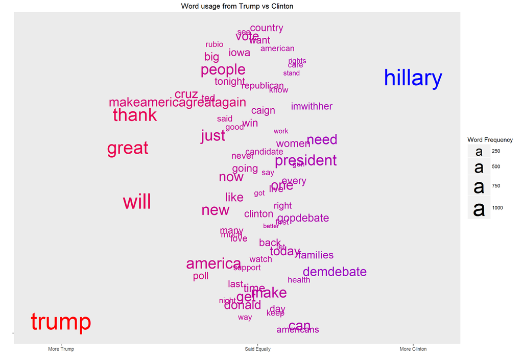

```r
# Load the tweets from the data folder
candidates <- Corpus(DirSource("candidates/"))

# Create a word cloud comparing Hillary Clinton's word usage to Donald Trump's
wordcloud(candidates[c(2,3)], "Clinton", "Trump")
```

Next we will analyze the sentiment of the tweets from each candidate. This function will take in all of the tweets from a dataset, and analyze the total number of words of emotive words in the tweets. Each tweet could have words that are positive and words that are negative - they are graded on a word-by-word basis. The data is then divided by the total word count, producing a table of the percentage of words that are emotive.

```r
# Create data frame
df <- data.frame(row.names=c("anger", "anticipation","disgust","fear","joy","sadness", "surprise","trust","negative", "positive"))

# Get sentiment scores for each data set
for (d in 1:length(candidates)) {
  df <- cbind(df,colSums(score.sentiment(candidates[[d]]$content))/length(unlist(strsplit(unlist(candidates[[d]]$content), " ")))*100)
}
# Add colnames
colnames(df) <- list.files("candidates")

# Transpose
df <- as.data.frame(t(df))

# Remove row names
df <- add_rownames(df, "data")

# Print the data frame
knitr::kable(df, format="markdown", digits=2, caption="Percentage of words of each emotion")
```

| data | anger | anticipation | disgust | fear | joy | sadness | surprise | trust | negative | positive |
| --- | --- | --- | --- | --- | --- | --- | --- | --- | --- | --- |
| BernieSanders.csv | 2.29 | 0.84 | 2.36 | 2.12 | 1.54 | 3.19 | 3.71 | 2.00 | 3.62 | 5.88 |
| HillaryClinton.csv | 2.09 | 0.78 | 2.15 | 1.51 | 1.23 | 2.76 | 3.72 | 2.13 | 3.38 | 6.04 |
| realdonaldtrump.csv | 1.92 | 1.27 | 1.60 | 2.05 | 2.81 | 2.54 | 3.59 | 2.12 | 3.62 | 5.38 |

Next we will analyze the data. First we will create a barplot of the data to visualize it, then perform a MANOVA as well as ANOVAs on the positive and negative tweets.

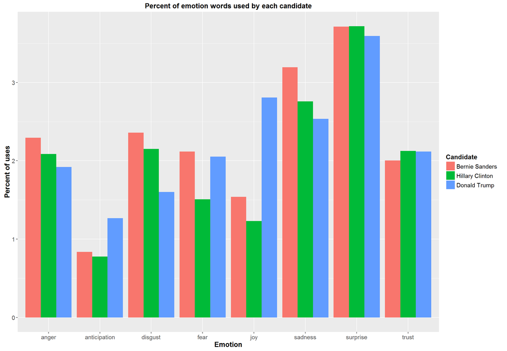

```r
# Now we will plot the data
gdf <- gather(df, emotion, count, 2:9)
ggplot(gdf, aes(x=emotion, y=count, fill=data))+geom_bar(stat="identity", position="dodge")+xlab("Emotion")+ylab("Percent of uses")+ggtitle("Percent of emotion words used by each candidate")+
  theme(axis.text=element_text(size=11), axis.title=element_text(size=13),
        title=element_text(face="bold"),
        legend.text=element_text(size=11), legend.title=element_text(size=12),
        strip.text=element_text(size=11))+scale_fill_discrete(name = "Candidate", labels = c("Bernie Sanders", "Hillary Clinton", "Donald Trump"))
```

```r
# Get full data frames of sentiment for analysis
full<-data.frame()
for (d in 1:length(candidates)) {
  full <- rbind(full,cbind(d, score.sentiment(candidates[[d]]$content)))
}

# Run MANOVA
manova.full <- manova(cbind(full[, 2], full[, 3], full[, 4], full[, 5], full[, 6],
                            full[, 7], full[, 8], full[, 9], full[, 10], full[, 11]) ~ as.factor(d), data = full)

summary(manova.full, test = "Pillai")
```

```
##                Df  Pillai approx F num Df den Df                Pr(>F)
## as.factor(d)    2 0.10332   52.118     20  19136 < 0.00000000000000022 ***
## Residuals    9576
## ---
## Signif. codes:  0 '***' 0.001 '**' 0.01 '*' 0.05 '.' 0.1 ' ' 1
```

```r
# Run ANOVA on individual columns
anova.full.negative <- aov(negative ~ as.factor(d), data = full)
summary(anova.full.negative)
```

```
##                Df Sum Sq Mean Sq F value   Pr(>F)
## as.factor(d)    2     12   6.141   8.305 0.000249 ***
## Residuals    9576   7080   0.739
## ---
## Signif. codes:  0 '***' 0.001 '**' 0.01 '*' 0.05 '.' 0.1 ' ' 1
```

```r
pairwise.t.test(full$negative, full$d, p.adj = "bonf")
```

```
##
##  Pairwise comparisons using t tests with pooled SD
##
## data:  full$negative and full$d
##
##   1       2
## 2 0.00014 -
## 3 0.17559 0.08832
##
## P value adjustment method: bonferroni
```

```r
TukeyHSD(anova.full.negative)
```

```
##   Tukey multiple comparisons of means
##     95% family-wise confidence level
##
## Fit: aov(formula = negative ~ as.factor(d), data = full)
##
## $`as.factor(d)`
##            diff          lwr          upr     p adj
## 2-1 -0.08760085 -0.138026824 -0.037174871 0.0001389
## 3-1 -0.04073165 -0.091197120  0.009733827 0.1410275
## 3-2  0.04686920 -0.003576559  0.097314961 0.0750418
```

```r
anova.full.positive <- aov(positive ~ as.factor(d), data = full)
summary(anova.full.positive)
```

```
##                Df Sum Sq Mean Sq F value       Pr(>F)
## as.factor(d)    2     35  17.587   17.01 0.0000000422 ***
## Residuals    9576   9900   1.034
## ---
## Signif. codes:  0 '***' 0.001 '**' 0.01 '*' 0.05 '.' 0.1 ' ' 1
```

```r
pairwise.t.test(full$positive, full$d, p.adj = "bonf")
```

```
##
##  Pairwise comparisons using t tests with pooled SD
##
## data:  full$positive and full$d
##
##   1           2
## 2 0.10320     -
## 3 0.000000025 0.00078
##
## P value adjustment method: bonferroni
```

```r
TukeyHSD(anova.full.positive)
```

```
##   Tukey multiple comparisons of means
##     95% family-wise confidence level
##
## Fit: aov(formula = positive ~ as.factor(d), data = full)
##
## $`as.factor(d)`
##            diff        lwr          upr     p adj
## 2-1 -0.05381740 -0.1134449  0.005810102 0.0867148
## 3-1 -0.14676661 -0.2064408 -0.087092402 0.0000000
## 3-2 -0.09294921 -0.1526001 -0.033298312 0.0007629
```

### Presidential Debate Sentiment Results

A multiple analysis of variance test was applied to the amount of emotion in the tweets related to the presidential candidates. The result was a p-value of less than 0.05. At the 0.05 significance level, we conclude that the true mean vectors of emotions per tweet: anger, anticipation, disgust, fear, joy, sadness, surprise, trust, negative, and positive, are jointly significant different for at least two of the presidential candidates.

We will repeat this code for the MLB datasets.

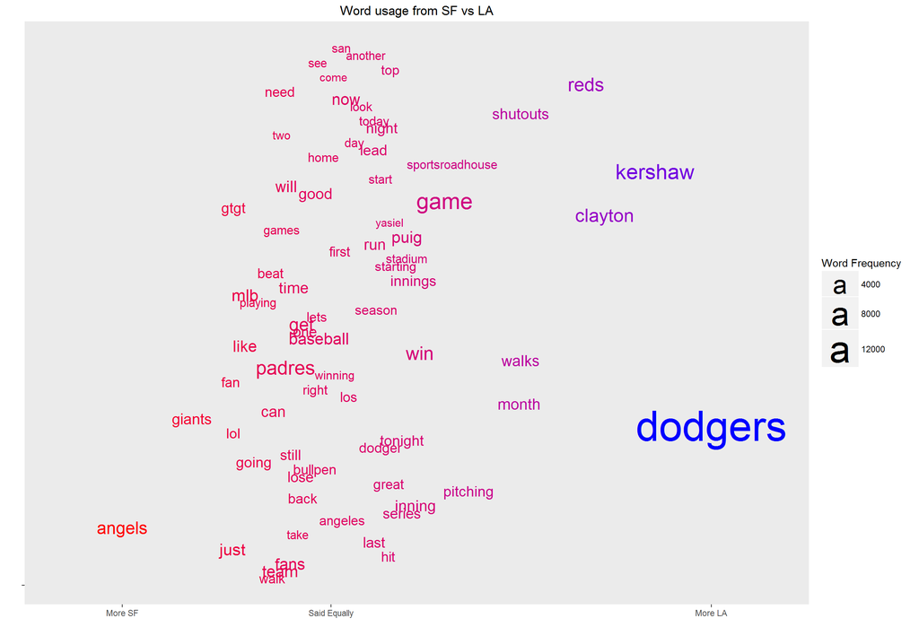

```r
# Load the tweets from the data folder
baseball <- Corpus(DirSource("baseball/"))

# Create a word cloud comparing the tweets about the Dodgers in the two cities.
wordcloud(baseball[c(1,2)], "LA", "SF")
```

Next we will analyze the sentiment of the tweets from each city.

```r
# Create data frame
df <- data.frame(row.names=c("anger", "anticipation","disgust","fear","joy","sadness", "surprise","trust","negative", "positive"))

# Get sentiment scores for each data set
for (d in 1:length(baseball)) {
  df <- cbind(df,colSums(score.sentiment(baseball[[d]]$content))/length(unlist(strsplit(unlist(baseball[[d]]$content), " ")))*100)
}
# Add colnames
colnames(df) <- list.files("baseball")

# Transpose
df <- as.data.frame(t(df))

# Remove row names
df <- add_rownames(df, "data")

# Print the data frame
knitr::kable(df, format="markdown", digits=2, caption="Percentage of words of each emotion")
```

| data | anger | anticipation | disgust | fear | joy | sadness | surprise | trust | negative | positive |
| --- | --- | --- | --- | --- | --- | --- | --- | --- | --- | --- |
| Dodgers_LA.csv | 1.21 | 1.05 | 1.17 | 1.34 | 1.33 | 2.37 | 2.31 | 1.65 | 2.44 | 3.41 |
| Dodgers_SF.csv | 1.65 | 1.29 | 1.42 | 1.73 | 1.41 | 2.49 | 2.55 | 1.70 | 3.23 | 3.44 |
| Giants_LA.csv | 1.41 | 0.62 | 1.56 | 0.99 | 0.96 | 2.22 | 3.88 | 3.04 | 2.56 | 6.53 |
| Giants_SF.csv | 1.20 | 0.55 | 1.06 | 1.10 | 1.45 | 2.41 | 2.63 | 1.94 | 2.39 | 3.90 |

Next we will analyze the data. First we will create a barplot of the data to visualize it, then perform a MANOVA as well as ANOVAs on the positive and negative tweets.

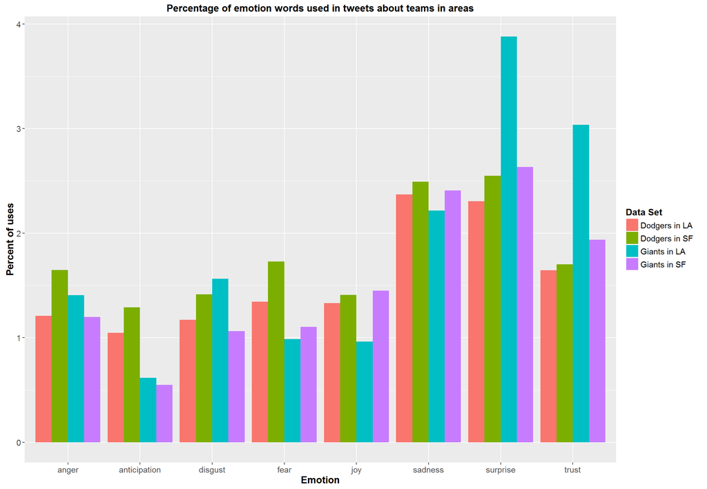

```r
# Now we will plot the data
gdf <- gather(df, emotion, count, 2:9)
ggplot(gdf, aes(x=emotion, y=count, fill=data))+geom_bar(stat="identity", position="dodge")+xlab("Emotion")+ylab("Percent of uses")+ggtitle("Percentage of emotion words used in tweets about teams in areas")+
  theme(axis.text=element_text(size=11), axis.title=element_text(size=13),
        title=element_text(face="bold"),
        legend.text=element_text(size=11), legend.title=element_text(size=12),
        strip.text=element_text(size=11))+scale_fill_discrete(name = "Data Set", labels = c("Dodgers in LA", "Dodgers in SF", "Giants in LA", "Giants in SF"))
```

```r
# Get full data frames of sentiment for analysis
full<-data.frame()
for (d in 1:length(baseball)) {
  full <- rbind(full,cbind(d, score.sentiment(baseball[[d]]$content)))
}

# Run MANOVA
manova.full <- manova(cbind(full[, 2], full[, 3], full[, 4], full[, 5], full[, 6],
                            full[, 7], full[, 8], full[, 9], full[, 10], full[, 11]) ~ as.factor(d), data = full)

summary(manova.full, test = "Pillai")
```

```
##                 Df  Pillai approx F num Df den Df                Pr(>F)
## as.factor(d)     3 0.10267   139.65     30 118233 < 0.00000000000000022
## Residuals    39418
##
## as.factor(d) ***
## Residuals
## ---
## Signif. codes:  0 '***' 0.001 '**' 0.01 '*' 0.05 '.' 0.1 ' ' 1
```

```r
# Run ANOVA on individual columns
anova.full.negative <- aov(negative ~ as.factor(d), data = full)
summary(anova.full.negative)
```

```
##                 Df Sum Sq Mean Sq F value              Pr(>F)
## as.factor(d)     3     80  26.627   75.71 <0.0000000000000002 ***
## Residuals    39418  13863   0.352
## ---
## Signif. codes:  0 '***' 0.001 '**' 0.01 '*' 0.05 '.' 0.1 ' ' 1
```

```r
pairwise.t.test(full$negative, full$d, p.adj = "bonf")
```

```
##
##  Pairwise comparisons using t tests with pooled SD
##
## data:  full$negative and full$d
##
##   1                    2                    3
## 2 < 0.0000000000000002 -                    -
## 3 0.0000004581337      0.0000000000075      -
## 4 1                    < 0.0000000000000002 0.0000004884446
##
## P value adjustment method: bonferroni
```

```r
TukeyHSD(anova.full.negative)
```

```
##   Tukey multiple comparisons of means
##     95% family-wise confidence level
##
## Fit: aov(formula = negative ~ as.factor(d), data = full)
##
## $`as.factor(d)`
##            diff         lwr         upr     p adj
## 2-1  0.10718019  0.08591674  0.12844364 0.0000000
## 3-1  0.04650404  0.02428342  0.06872466 0.0000005
## 4-1  0.00009999 -0.02144511  0.02164509 0.9999994
## 3-2 -0.06067615 -0.08262379 -0.03872851 0.0000000
## 4-2 -0.10708020 -0.12834365 -0.08581675 0.0000000
## 4-3 -0.04640405 -0.06862467 -0.02418343 0.0000005
```

```r
anova.full.positive <- aov(positive ~ as.factor(d), data = full)
summary(anova.full.positive)
```

```
##                 Df Sum Sq Mean Sq F value              Pr(>F)
## as.factor(d)     3   1247   415.6   780.9 <0.0000000000000002 ***
## Residuals    39418  20981     0.5
## ---
## Signif. codes:  0 '***' 0.001 '**' 0.01 '*' 0.05 '.' 0.1 ' ' 1
```

```r
pairwise.t.test(full$positive, full$d, p.adj = "bonf")
```

```
##
##  Pairwise comparisons using t tests with pooled SD
##
## data:  full$positive and full$d
##
##   1                    2                    3
## 2 0.39                 -                    -
## 3 < 0.0000000000000002 < 0.0000000000000002 -
## 4 0.00000000028        0.00000872919        < 0.0000000000000002
##
## P value adjustment method: bonferroni
```

```r
TukeyHSD(anova.full.positive)
```

```
##   Tukey multiple comparisons of means
##     95% family-wise confidence level
##
## Fit: aov(formula = positive ~ as.factor(d), data = full)
##
## $`as.factor(d)`
##            diff          lwr         upr     p adj
## 2-1  0.01883448 -0.007323971  0.04499293 0.2500943
## 3-1  0.45038455  0.423048586  0.47772052 0.0000000
## 4-1  0.06789321  0.041388275  0.09439815 0.0000000
## 3-2  0.43155007  0.404549924  0.45855022 0.0000000
## 4-2  0.04905873  0.022900279  0.07521718 0.0000086
## 4-3 -0.38249134 -0.409827308 -0.35515538 0.0000000
```

### MLB Sentiment Results

A multiple analysis of variance test was applied to the amount of emotion in the tweets in Los Angeles and San Francisco related the Dodgers and Giants. The result was a p-value of less than 0.05. At the 0.05 significance level, we conclude that the true mean vectors of emotions per tweet (i.e. anger, anticipation, disgust, fear, joy, sadness, surprise, trust, negative, and positive) have jointly significant differences for at least two populations of tweets regarding the Dodgers and Giants in Los Angeles and San Francisco.

Looking at the data table of MLB teams, 2.44% of Los Angeles’s tweets regarding the Dodgers, 3.23% of San Francisco’s tweets regarding the Dodgers, 2.56% of Los Angeles’s tweets regarding the Giants, and 2.39% of San Francisco’s tweets regarding the Giants contained negative words. An ANOVA test was applied to the mean amount of negative words in the MLB tweets and resulted in a p-value less than 0.05. At the 0.05 level of significance, we reject the null hypothesis and conclude that there is a significant difference in the true mean amount of negative words in the tweets of MLB teams in each city.

Based on the Tukey interval analysis, tweets about the Dodgers from the San Francisco region contain a significantly higher amount of negative words than tweets about the same team from the Los Angeles region. This is because the Tukey interval does not contain the value of 0; therefore, the conclusion that there is no difference between the two is not plausible at the 95% confidence level. We are 95% confident that the difference in average number of negative words in tweets is between 0.086 and 0.128.

Tweets about the Giants from the Los Angeles region contain a significantly higher amount of negative words than tweets about the Dodgers from the Los Angeles region. This is because the Tukey interval does not contain the value of 0; therefore the conclusion that there is no difference between the two is not plausible at the 95% confidence level. We are 95% confident that the difference in average number of negative words in tweets is between 0.024 and 0.069.

Tweets about the Dodgers from the San Francisco region contain a significantly higher amount of negative words than tweets about the Giants from the Los Angeles region. This is because the Tukey interval does not contain the value of 0; therefore, the conclusion that there is no difference between the two is not plausible at the 95% confidence level. We are 95% confident that the difference in average number of negative words in tweets is between 0.039 and 0.083.

Tweets about the Dodgers from the San Francisco region contain a significantly higher amount of negative words than tweets about the Giants from the same region. This is because the Tukey interval does not contain the value of 0; therefore, the conclusion that there is no difference between the two is not plausible at the 95% confidence level. We are 95% confident that the difference in average number of negative words in tweets is between 0.086 and 0.128.

Tweets about the Giants from the Los Angeles region contain a significantly higher amount of negative words than tweets about the same team from the San Francisco region. This is because the Tukey interval does not contain the value of 0; therefore, the conclusion that there is no difference between the two is not plausible at the 95% confidence level. We are 95% confident that the difference in average number of negative words in tweets is between 0.024 and 0.068.

Looking at the data table of MLB teams, 3.41% of tweets regarding the Dodgers from Los Angeles, 3.44% of tweets regarding the Dodgers from San Francisco, 6.53% of tweets regarding the Giants from Los Angeles, and 3.90% of tweets regarding the Giants from San Francisco contained positive words. An ANOVA test was applied to the mean amount of positive words in the MLB tweets and resulted with a p-value of less than 0.05. At the 0.05 level of significance, we reject the null hypothesis and conclude that there is a significant difference in the true mean amount of positive words in the tweets of MLB teams in each city.

Based on the Tukey interval analysis, tweets about the Giants from the Los Angeles region contain a significantly higher amount of positive words than tweets about the Dodgers from the same Los Angeles region. We reached this conclusion because the Tukey interval does not contain the value of 0; therefore, the conclusion that there is no difference between the two is not plausible at the 95% confidence level. We are 95% confident that the difference in average number of negative words in tweets is between 0.423 and 0.478.

Tweets about the Giants from the San Francisco region contain a significantly higher amount of positive words than tweets about the Dodgers from the Los Angeles region. This is because the Tukey interval does not contain the value of 0; therefore, the conclusion that there is no difference between the two is not plausible at the 95% confidence level. We are 95% confident that the difference in average number of negative words in tweets is between 0.041 and 0.094.

Tweets about the Giants from the San Francisco region contain a significantly higher amount of positive words than tweets about the Dodgers from the same region. This is because the Tukey interval does not contain the value of 0; therefore, the conclusion that there is no difference between the two is not plausible at the 95% confidence level. We are 95% confident that the difference in average number of negative words in tweets is between 0.023 and 0.075.

Tweets about the Giants from the Los Angeles region contain a significantly higher amount of positive words than tweets about the same team from the San Francisco region. This is because the Tukey interval does not contain the value of 0; therefore, the conclusion that there is no difference between the two is not plausible at the 95% confidence level. We are 95% confident that the difference in average number of negative words in tweets is between 0.355 and 0.410.

## **Conclusion**

For the MLB analysis over 8,871 tweets per city regarding Dodgers and Giants were analyzed. Finding show that “Dodgers”, “Clayton”, “Kershaw” and “reds” were the most repeatedly tweeted words in Los Angeles while “Angels”, “Giants”, “mlb” and “just” were in San Francisco. There was more negative words used in both MLB hometowns toward the opposing team. San Francisco had more negative words in their tweets regarding the Dodgers than Los Angeles had toward the Giants. Additionally, it was also found that Los Angeles’s tweets regarding the Giants had more positive words than its tweets toward the Dodgers. San Francisco’s tweets regarding its home team had more positive words than Los Angeles’s tweets regarding its home team. Los Angeles’s tweets regarding the Giants had more positive tweets than San Francisco regarding the Dodgers. San Francisco had more positive tweets about that Giants than the Dodgers. Los Angeles had more positive tweet about the Giants than San Francisco did.

This suggests each city is more likely to tweet something negative about the opposing team than something negative about their home team. San Francisco tweets more negatively about the Dodgers than Los Angeles does about the Giants. Additionally, San Francisco tweets more positively about its team than Los Angeles does about its team. Surprisingly, both cities tweet had more positive words regarding the Giants over the Dodgers.

## **References**

- https://github.com/drewconway/ZIA/blob/master/R/better_word_cloud/better_word_cloud.R
- http://saifmohammad.com/WebPages/NRC-Emotion-Lexicon.htm
- http://www.text-analytics101.com/2011/05/opinion-mining.html
- http://blog.datumbox.com/10-tips-for-sentiment-analysis-projects/
- https://en.m.wikipedia.org/wiki/Sentiment_analysi
- https://www.revinate.com/blog/2015/10/three-practical-uses-sentiment-analysis/
- http://www.r-bloggers.com/twitter-sentiment-analysis-with-r/
- https://www.credera.com/blog/technology-insights/open-source-technology-insights/twitter-analytics-using-r-part-3-compare-sentiments/

## Full code of functions

- spread - makes large numbers smaller and small numbers larger to make words more visible

```r
spread <- function(x) {
  return(sapply(x, function(x) {
    if (x == 0) {
      return(0)
    } else if (x < 0) {
      return(-1*abs(x)^(7/9))
    } else {
      return(x^(7/9))
    }
  }))
}
```

- clean.text - uses Regular Expressions to clean out tweets of punctuation, links, handles (@…).

```r
clean.text <- function(to_clean) {
  # Removes RT, via, @..., punctuation, digits, links, starting/ending whitespace, and some unicode characters
  to_clean <- gsub("(RT|via)((?:\\b\\W*@\\w+)+)", "", to_clean)    # remove RT @... and via @...
  to_clean <- gsub("@\\w+", "", to_clean)                          # remove any @...
  to_clean <- gsub("[[:punct:]]", "", to_clean)
  to_clean <- gsub("[[:digit:]]", "", to_clean)
  to_clean <- gsub("http\\w+", "", to_clean)
  to_clean <- gsub("^\\s+|\\s+$", "", to_clean)
  to_clean <- gsub("amp", "", to_clean)
  to_clean <- gsub("[^[:alnum:] ]", "", to_clean)

  # converts to lowercase
  to_clean <- sapply(to_clean, tolower)
  to_clean <- to_clean[to_clean != ""]
  names(to_clean) <- NULL
  return(to_clean)
}
```

- wordcloud - generates a word cloud, given two input files.

```r
wordcloud <- function(timelines, first="First", second="Second") {

  # Gets the number of words from each data set
  first.wc <- length(unlist(strsplit(unlist(timelines[[1]]$content), " ")))
  second.wc <- length(unlist(strsplit(unlist(timelines[[2]]$content), " ")))

  # Creates a matrix containing the number of times each word is said, ignoring common english words (and, this, the)
  timelines <- tm_map(timelines, removeWords, stopwords())
  timelines <- tm_map(timelines, removeWords, clean.text(stopwords()))
  add.stops=c("")
  timeline.control<-list(stopwords=c(stopwords(),add.stops), removeNumbers=TRUE, removePunctuation=TRUE)
  timelines.matrix<-TermDocumentMatrix(timelines, control=timeline.control)

  # Creates columns for the difference in word use, by count and percentage
  timelines.df<-as.data.frame(as.matrix(timelines.matrix))
  timelines.df$freq.dif <- timelines.df[,1] - timelines.df[,2]
  timelines.df$use <- timelines.df[,1] + timelines.df[,2]
  timelines.df[,1] <- timelines.df[,1]/first.wc
  timelines.df[,2] <- timelines.df[,2]/second.wc
  timelines.df$freq.dif.perc <- timelines.df[,1] - timelines.df[,2]

  # Gets only the top 75 words
  data <- timelines.df[timelines.df$use > sort(timelines.df$use, decreasing = T)[75], ]

  # Creates the plot
  ggplot(data, aes(x=spread(freq.dif.perc), y=sample(1:length(freq.dif.perc)))) + # spread makes large numbers small and small numbers larger
    geom_text(aes(label=row.names(data), size=use, color=freq.dif.perc)) +
    scale_y_continuous(breaks=c(0),labels=c("")) +
    scale_size(range=c(3,15), name="Word Frequency") +
    scale_colour_gradient(low="red", high="blue", guide="none") +
    xlab("") +
    ylab("") +
    ggtitle(paste("Word usage from", second, "vs", first)) +
    scale_x_continuous(limits=c(min(spread(data$freq.dif.perc)) - .005, max(spread(data$freq.dif.perc) + .005)),
                       breaks = c(min(spread(data$freq.dif.perc)), 0, max(spread(data$freq.dif.perc))),
                       labels=c(paste("More", second),"Said Equally",paste("More", first))) +
    theme(panel.grid.major=element_blank(), panel.grid.minor=element_blank())
}
```

- get.tweets.user/get.tweets.search - downloads last n tweets from specified users or specified search

```r
get.tweets.user <- function(users, consumer_key, consumer_secret, access_token, access_secret, num = 1000) {
  setup_twitter_oauth(consumer_key, consumer_secret, access_token, access_secret)

  for (user in users) {
    tweets <- userTimeline(user, n = num, includeRts = T)
    tweets.text <- clean.text(sapply(tweets, function(x) x$getText()))
    write.csv(tweets.text, file=paste("./data/", user, ".csv", sep=""), row.names = FALSE)
  }
}

get.tweets.search <- function(searches, consumer_key, consumer_secret, access_token, access_secret, num = 1000) {
  setup_twitter_oauth(consumer_key, consumer_secret, access_token, access_secret)

  for (search in searches) {
    tweets <- searchTwitter(search, n = num, includeRts = T) # Get tweets
    tweets.text <- clean.text(sapply(tweets, function(x) x$getText())) # Clean tweets
    write.csv(tweets.text, file=paste("./data/", search, ".csv", sep=""), row.names = FALSE) # Write tweets to file
  }
}
```

- score.sentiment - gets a score indicating whether the sentences are mostly positive, negative, or neutral.

```r
score.sentiment <- function(text){
  load("nrc_dictionary.RDATA")
  split_words <- strsplit(tolower(text), "[^A-Za-z']+")
  nrc_data <- lapply(split_words, function(word_vector){
    colSums(nrc[which(rownames(nrc) %in% word_vector), ])
  })
  result_df <- as.data.frame(do.call(rbind, nrc_data), stringsAsFactors=FALSE)
  # reorder the columns
  emotions_order <- c(
    "anger",
    "disgust",
    "fear",
    "sadness",
    "surprise",
    "anticipation",
    "trust",
    "joy",
    "negative",
    "positive"
  )
  result_df[, emotions_order]
}
```